# index

João Martins – Analista de Dados Introdução

João Martins é um analista de dados apaixonado por transformar números em conhecimento estratégico. Com experiência em diversas áreas de negócios, ele utiliza estatística, programação e visualização para apoiar decisões e gerar valor para as empresas.

Formação Acadêmica

Graduação em Estatística – Universidade Federal de Minas Gerais (UFMG)

Pós-graduação em Ciência de Dados e Big Data – Fundação Getulio Vargas (FGV)

Experiência Profissional Analista de Dados Pleno – TechInsights (2021 – Atual)

Criação de dashboards interativos no Power BI e Tableau para monitorar indicadores de performance.

Desenvolvimento de modelos preditivos em Python e R para prever demanda de clientes.

Otimização de processos de ETL em SQL, reduzindo o tempo de processamento em 40%.

Analista Júnior – DataCorp (2019 – 2021)

Extração e tratamento de grandes volumes de dados utilizando SQL e Spark.

Apoio em projetos de machine learning voltados para segmentação de clientes.

Automatização de relatórios diários, reduzindo esforço manual da equipe.

Habilidades Técnicas

Linguagens: Python, R, SQL

Ferramentas: Power BI, Tableau, Excel avançado

Big Data: Spark, Hadoop

Modelagem: Regressão, classificação, séries temporais

Projetos de Destaque Modelo de Previsão de Vendas

Criou um modelo preditivo que ajudou uma rede de varejo a estimar a demanda semanal por produto, reduzindo rupturas em 25%.

Segmentação de Clientes

Implementou um modelo de clustering para identificar perfis de consumo e apoiar campanhas de marketing direcionadas, aumentando em 18% a taxa de conversão.

Perfil Pessoal

João é curioso por natureza, gosta de resolver problemas complexos e acredita que dados bem trabalhados podem mudar a forma como as empresas enxergam seu negócio. Além do ambiente profissional, é entusiasta de maratonas de programação e mentor voluntário em projetos de educação em tecnologia.

```python
2 + 2
```

```
4
```

|  | Categoria | Valor |
| --- | --- | --- |
| 0 | A | 23 |
| 1 | B | 45 |
| 2 | C | 56 |
| 3 | D | 12 |
| 4 | E | 39 |

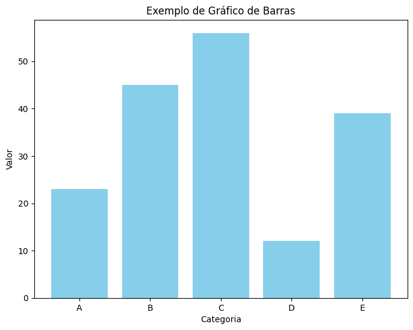

```python
import pandas as pd
import matplotlib.pyplot as plt

# Create a sample DataFrame
data = {'Categoria': ['A', 'B', 'C', 'D', 'E'],
        'Valor': [23, 45, 56, 12, 39]}
df = pd.DataFrame(data)

# Display the DataFrame
display(df)

# Create a bar plot
plt.figure(figsize=(8, 6))
plt.bar(df['Categoria'], df['Valor'], color='skyblue')
plt.xlabel('Categoria')
plt.ylabel('Valor')
plt.title('Exemplo de Gráfico de Barras')
plt.show()
```